# randomForestOnPCs

Ian Douglas

9/25/2019

```r
library(randomForest)
library(tidyverse)
```

Load in each PC solution, age, & PI/Comp designation

```r
cPCA = readRDS("../results/PCA/funcConnectivityPCAobj.rds")
dPCA = readRDS("../results/PCA/funcDissimilarityPCAobj.rds")
corPCAlbl = readRDS('../data/labels/funcConnlbls.rds')
distPCAlbl = readRDS('../data/labels/funcDistlbls.rds')
# Combine each as a data frame
pcRFcor.dat = na.omit(as.data.frame(cbind(corPCAlbl,cPCA$x)))
pcRFdiss.dat = na.omit(as.data.frame(cbind(distPCAlbl,dPCA$x)))
```

```
Note, for the following analyses, we will use the PC solution called "cPCA" above, generated from the Pearson correlation features, because they were highly overlapping with the PCs generated from the features that were built on the Pearson Corrleation dissimilarity measure.
```

# 1 Predict age with the PCs

### 1.0.1 Baseline solution with default hyperparameters on the correlation-based PCs

```r
#set a randomization seed for reproducibility
set.seed(111)
# Create a training, test and hold-out set
```

#### 1.0.1.1 Predicting age

```r
#randomForest::randomForest()
ageRFcor = randomForest(
  age ~ .-GROUP-IDENT_SUBID, data = pcRFcor.dat,
  mtry = sqrt(ncol(cPCA$x)), # this is the default in sklearn
  importance = TRUE)
saveRDS(ageRFcor,"../results/RF/ageRFcor.rds")
# Results:
corTreeRes=data.frame(na.omit(corPCAlbl), stringsAsFactors = FALSE,
           "age_pred" = predict(ageRFcor)) %>%
  mutate(ageDiff = age - age_pred) %>%
  group_by(GROUP) %>%
  summarize(avg_pred = mean(ageDiff),
            rmse = sqrt(mean(ageDiff^2)),
            pred_sd = sd(ageDiff),
            prior_avg = mean(age), prior_sd = sd(age),
            n = n())
write.csv(corTreeRes, "../results/RF/corTreeTblBaseline.csv")
corTreeRes
```

| GROUP | avg_pred | rmse | pred_sd | prior_avg | prior_sd | n |
| --- | --- | --- | --- | --- | --- | --- |
| COMP | -0.3253368 | 3.759055 | 3.767442 | 10.24802 | 3.859999 | 84 |
| PI | 0.1821565 | 2.904742 | 2.923084 | 10.68989 | 2.961447 | 61 |

*Results*: On average, the predicted age for the PI group is ~.18 years (about 2 months) younger than their actual age, while Comp predictions tend to overshoot their actaul age by about 4 months. However, the ~6-year wide confidence region around those estimates could mean that the exact opposite is just as plausible.

### 1.0.2 Baseline solution with default hyperparameters on the dissimilarity-based PCs

```r
#randomForest::randomForest()
ageRFdis = randomForest(
  age ~ .-GROUP-IDENT_SUBID, data = pcRFdiss.dat,
  mtry = sqrt(ncol(dPCA$x)), # this is the default in sklearn
  importance = TRUE)
saveRDS(ageRFdis,"../results/RF/ageRFdis.rds")
# Results:
disTreeRes=data.frame(na.omit(distPCAlbl), stringsAsFactors = FALSE,
           "age_pred" = predict(ageRFdis)) %>%
  mutate(ageDiff = age - age_pred) %>% #Raw error
  group_by(GROUP) %>%
  summarize(avg_pred = mean(ageDiff),
            rmse = sqrt(mean(ageDiff^2)),
            pred_sd = sd(ageDiff),
            prior_avg = mean(age), prior_sd = sd(age),
            n = n())
write.csv(disTreeRes, "../results/RF/distTreeTblBaseline.csv")
disTreeRes
```

| GROUP | avg_pred | rmse | pred_sd | prior_avg | prior_sd | n |
| --- | --- | --- | --- | --- | --- | --- |
| COMP | -0.2203114 | 3.725060 | 3.740873 | 10.24802 | 3.859999 | 84 |
| PI | 0.2158381 | 2.916984 | 2.933129 | 10.68989 | 2.961447 | 61 |

*Results*: The results are essentially the same for this method, with the exception that the bias of prediction decreased for Comps. However, the confidence intervals remain large.

*Conclusion*: the predictions are fairly unbiased, relative to the variance shown in those predictions. Either method appears to perform equally as well, with the caveat that the PCs built on dissimilarity distances resulted in less bias (aggregating across both groups), but this did not affeect the variance. The second model could be seen as *marginally* better. *Lastly*, the variance of the actual ages is almost equal to the variance of the predicted values, suggesting that this tree is not explaining very much of the variance at all.

# 2 Grid Search …in R?(!)

```
In R the apply() family of functions can conduct a vectorized grid search over tunable hyperparameters.
```

### 2.0.1 Prepare grid

```r
param_grid = expand.grid(
  "ntree"= c(500, 750, 1000),
  "mtry"= c(seq(12,144,12)),
  "data" = c("cor","dist"), stringsAsFactors = FALSE
)
#prepare the data list
dataFrames = list("cor" = pcRFcor.dat, "dist" = pcRFdiss.dat)
head(param_grid[1:10,])
```

|  | ntree | mtry | data |
| --- | --- | --- | --- |
| 1 | 500 | 12 | cor |
| 2 | 750 | 12 | cor |
| 3 | 1000 | 12 | cor |
| 4 | 500 | 24 | cor |
| 5 | 750 | 24 | cor |
| 6 | 1000 | 24 | cor |

### 2.0.2 Prepare the model function

```r
# each column will be supplied (as a vector) to the function:
RF = function(x) {
  model = randomForest(
    age ~ .-GROUP-IDENT_SUBID, # know what is in your data in advance.
    ntree = as.numeric(x[1]), #x[1] = either 500, 750, or 1000
    mtry = as.numeric(x[2]), #x[2] = one of: seq(from=12,to=144,by=12)
    data = getElement(object =
                        getElement(
                          object = .GlobalEnv, "dataFrames"),
                      name = x[3]),
    importance = TRUE
  )
  return(model)
}
```

### 2.0.3 Evaluate

```r
# The output of apply will be a list, in which each object is one fit of RF
# the argument 1 means "operate on each row".
tree_search = apply(param_grid, 1, RF)
#saveRDS(tree_search, '../results/RF/allTrees.rds')
```

[output not shown]

```r
R.sqs = lapply(tree_search, function(x) tail(x$rsq, 1))
bestTreeRSQ = tree_search[[which.max(R.sqs)]]
bestTreeRSQ
```

```
##
## Call:
##  randomForest(formula = age ~ . - GROUP - IDENT_SUBID, data = getElement(object = getElement(object = .GlobalEnv,      "dataFrames"), name = x[3]), ntree = as.numeric(x[1]), mtry = as.numeric(x[2]),      importance = TRUE)
##                Type of random forest: regression
##                      Number of trees: 500
## No. of variables tried at each split: 108
##
##           Mean of squared residuals: 10.94956
##                     % Var explained: 10.29
```

```r
saveRDS(bestTreeRSQ, '../results/RF/bestTreeRSQ.rds')
c("best_params:", param_grid[which.max(R.sqs),])
```

```
## [[1]]
## [1] "best_params:"
##
## $ntree
## [1] 500
##
## $mtry
## [1] 108
##
## $data
## [1] "cor"
```

### 2.0.4 Plot variable importances

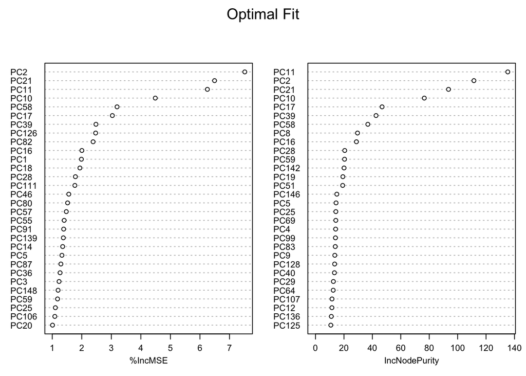

```r
varImpPlot(bestTreeRSQ, cex = .7, main = 'Optimal Fit')
```